# Лабораторная работа №8

## Состояние OSPFv2 после отказа

- Проверка `show ip ospf route`
- Пересчёт маршрутов
- Использование альтернативного пути через eth2
- Соседство OSPF сохранено

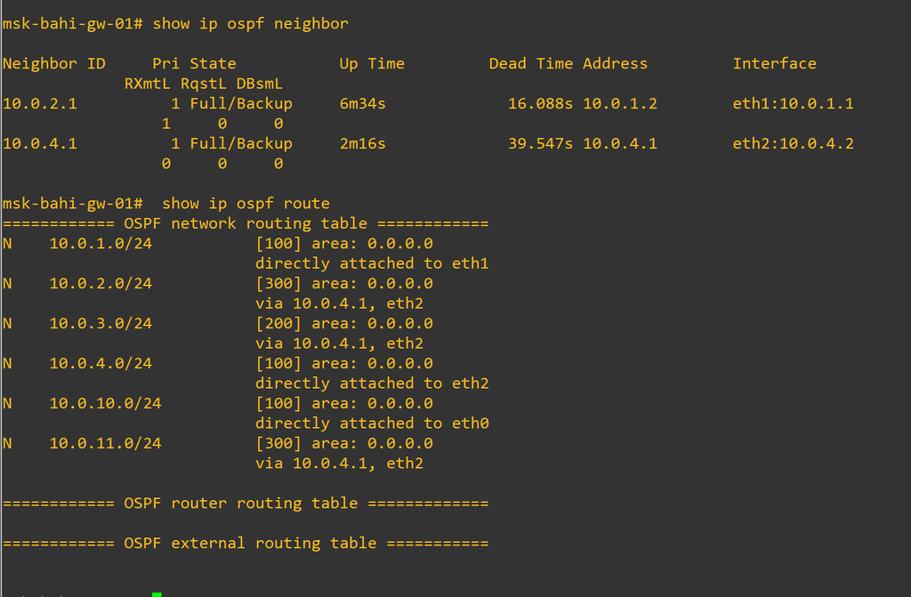

## Повторная проверка связности (OSPFv2)

- Ping PC1 → PC2 успешен
- Traceroute:
  - 10.0.10.1
  - 10.0.4.1
  - 10.0.3.1
  - 10.0.11.10

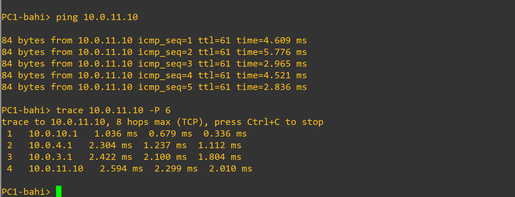

## Восстановление интерфейса msk-bahi-gw-02

- Команда: `no shutdown`
- Интерфейс eth0 снова активен

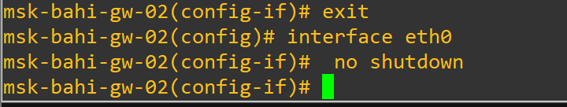

## Контроль связности после восстановления (OSPFv2)

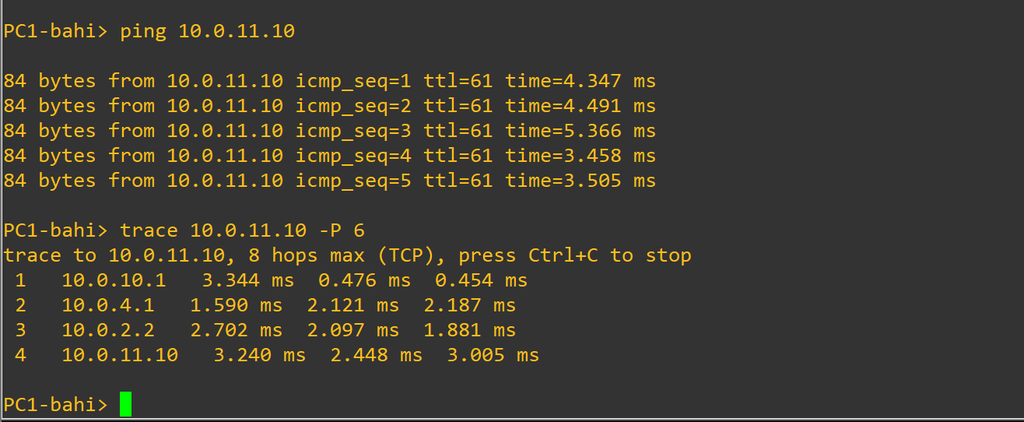

## Анализ ICMP и ARP трафика (IPv4)

- ARP-пакеты: сопоставление IP ↔︎ MAC
- ICMP Echo Request / Reply
- Уменьшение TTL
- Подтверждение прохождения через несколько маршрутизаторов

[figure not shown]

## ICMP Time Exceeded при трассировке

- ICMP Time-to-live exceeded
- Формируются промежуточными маршрутизаторами
- Используются для определения маршрута

[figure not shown]

## Служебный трафик OSPF и RIP

- OSPF Hello:
  - Multicast 224.0.0.5
- RIP v2:
  - Multicast 224.0.0.9
- Подтверждение одновременной работы RIP и OSPF

[figure not shown]

# Настройка OSPFv3 (IPv6)

## OSPFv3 на msk-bahi-gw-01

- Активация OSPFv3
- Router-ID: 1.1.1.1
- Включение на интерфейсах:
  - eth0
  - eth1
  - eth2
- Область: 0
- Сохранение конфигурации

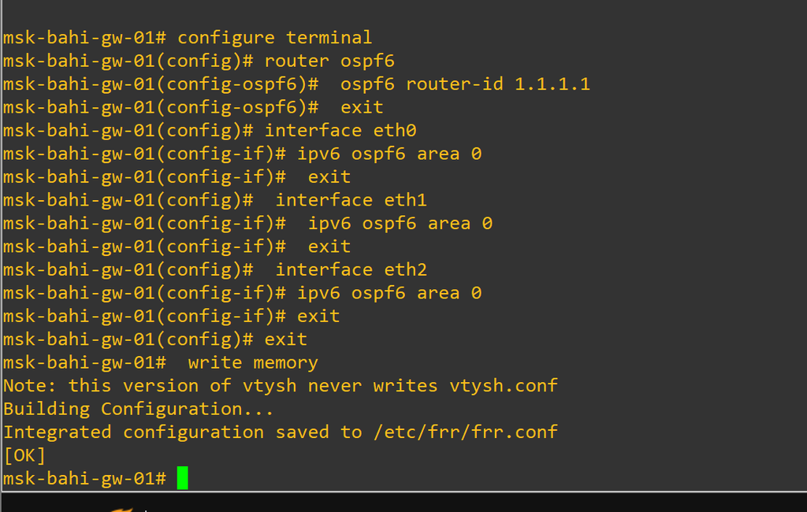

## OSPFv3 на msk-bahi-gw-02

- Router-ID: 2.2.2.2
- Активация OSPFv3
- Интерфейсы:
  - eth0
  - eth1
- Область: 0

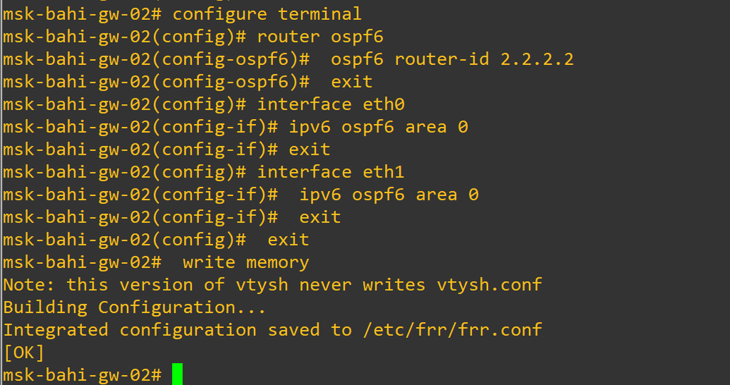

## OSPFv3 на msk-bahi-gw-03

- Router-ID: 3.3.3.3
- Интерфейсы:
  - eth0
  - eth1
  - eth2
- Участие всех IPv6-сегментов
- Сохранение конфигурации

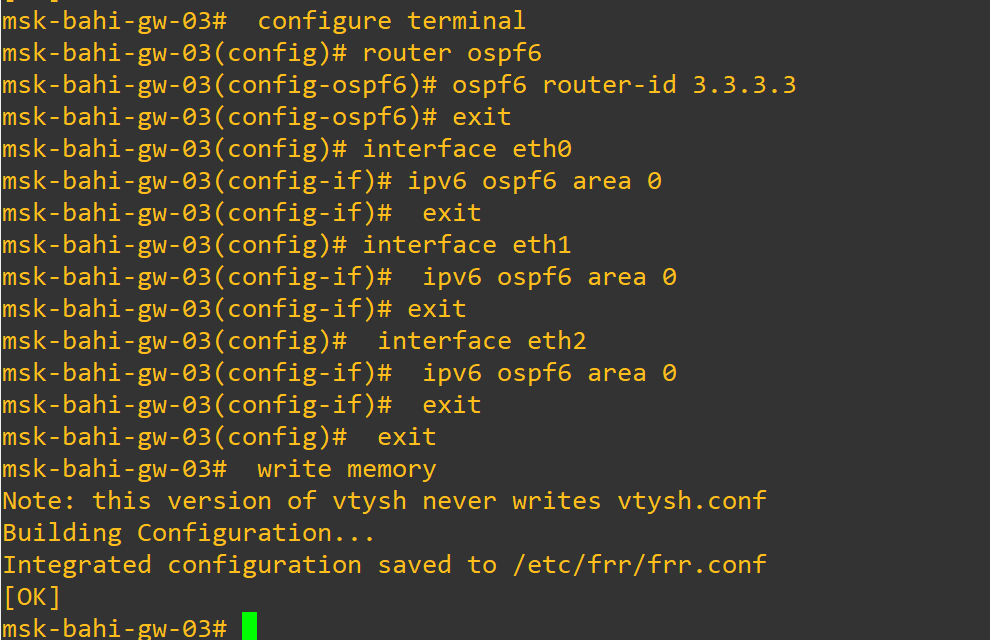

## OSPFv3 на msk-bahi-gw-04

- Router-ID: 4.4.4.4
- Интерфейсы:
  - eth0
  - eth1
- Область: 0

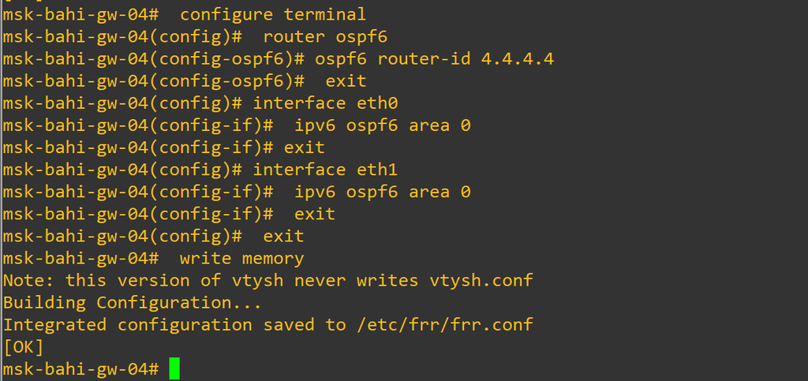

## Проверка связности IPv6 (OSPFv3)

- Ping `2001:11::a`
- Получены ICMPv6-ответы
- Hop limit = 58
- Traceroute:
  - 2001:10::1
  - 2001:1::2
  - 2001:2::2
  - 2001:11::a

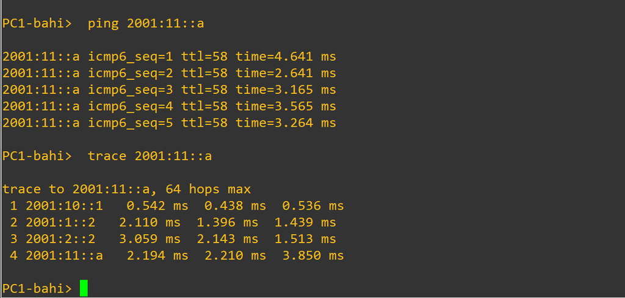

## Проверка соседства и маршрутов OSPFv3

- Команды:
  - `show ipv6 ospf6 neighbor`
  - `show ipv6 ospf6 route`
- Соседи:
  - 2.2.2.2
  - 4.4.4.4
- Состояние: Full/BDR
- IA-префиксы IPv6

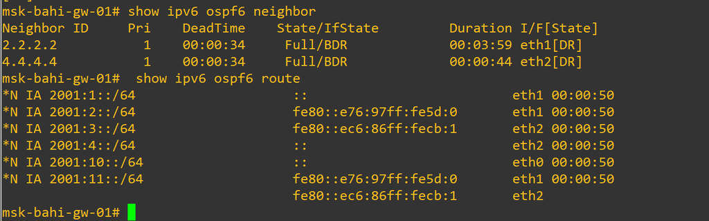

## Отказ интерфейса (OSPFv3)

- Отключение eth0
- Команда `shutdown`
- Выполнено на msk-bahi-gw-02

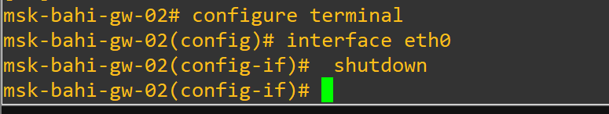

## Пересчёт маршрутов OSPFv3

- Проверка `show ipv6 ospf6 route`
- Выбор альтернативного next-hop
- Обновление таблицы маршрутов

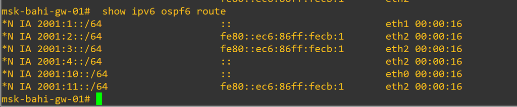

## Проверка связности после отказа (IPv6)

- Ping `2001:11::a` успешен
- Traceroute:
  - 2001:10::1
  - 2001:4::1
  - 2001:3::1
  - 2001:11::a

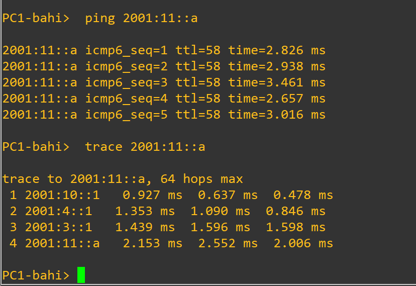

## Восстановление интерфейса (OSPFv3)

- Команда `no shutdown`
- Интерфейс eth0 восстановлен

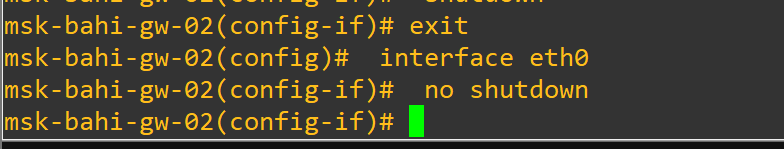

## Контрольная проверка IPv6-связности

- Ping успешен
- Traceroute фиксирует актуальный маршрут
- Работа OSPFv3 подтверждена

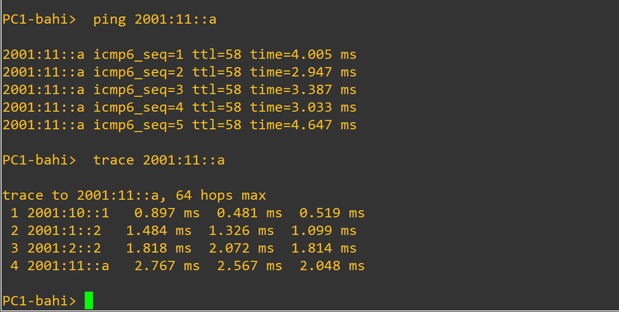

## Анализ перехваченного IPv6-трафика (ICMPv6)

- Зафиксированы ICMPv6 Echo Request и Echo Reply между узлами `2001:10::a` ↔︎ `2001:11::a`
- Подтверждена проверка связности на сетевом уровне
- Значения Hop Limit в ответах меньше исходных
- Зафиксировано прохождение пакетов через несколько маршрутизаторов
- В трассировке присутствуют ICMPv6 Time Exceeded
- Сообщения формируются промежуточными маршрутизаторами
- Используются для определения пути следования пакетов

[figure not shown]

## Служебный трафик OSPF, UDP и ICMPv6

- Зафиксированы OSPF Hello Packet
- Используются мультикаст-адреса:
  - ff02::5
  - 224.0.0.5
- Поддерживается OSPF-соседство между маршрутизаторами
- Зафиксированы UDP-пакеты
- Наблюдаются ICMPv6 Destination Unreachable (Port unreachable)
- Пакеты возникают при выполнении трассировки
- Анализ подтверждает:
  - активность протоколов маршрутизации
  - определение маршрута
  - реакцию сети на диагностические запросы

[figure not shown]

# Построение туннеля IPv6–IPv4

## Развёртывание топологии сети в GNS3

- Создан новый проект в GNS3
- Размещены маршрутизаторы VyOS, коммутаторы и узлы VPCS
- Топология включает:
  - два IPv6-сегмента
  - IPv4-транзитную сеть
  - логический IPv6-туннель
- Настроены имена устройств:
  - маршрутизаторы — `msk-user-gw-0x`
  - коммутаторы — `msk-user-sw-0x`
  - узлы — `PCx-user`
- Включён захват трафика между `msk-user-gw-01` и `msk-user-gw-03`

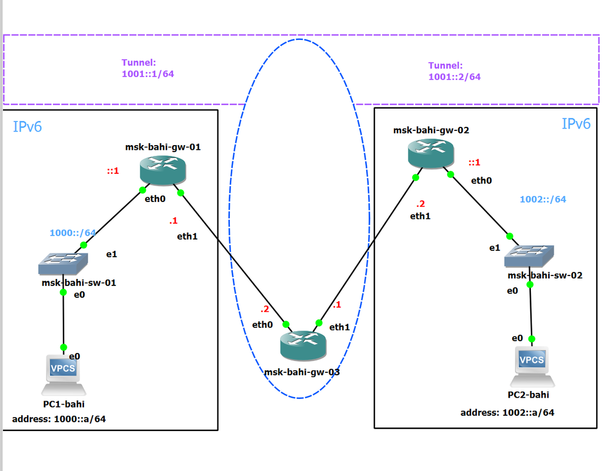

## Назначение IPv6-адресов оконечным устройствам

- На PC1-bahi настроен адрес:
  - `1000::a/64`
- На PC2-bahi настроен адрес:
  - `1002::a/64`
- Конфигурация сохранена
- Команда `show ipv6` подтвердила:
  - глобальные IPv6-адреса
  - link-local IPv6-адреса
- Настройка интерфейсов выполнена корректно

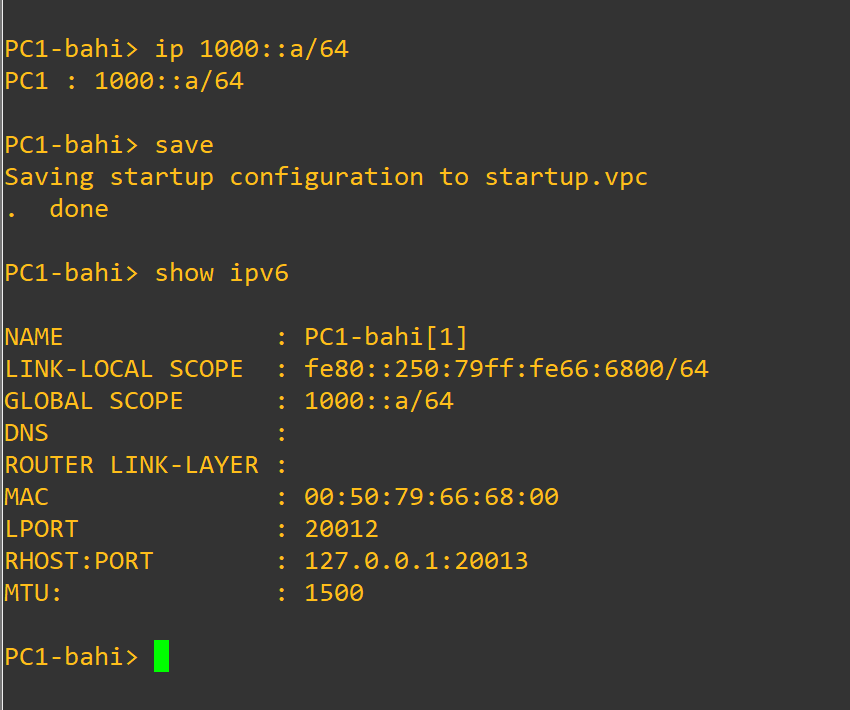

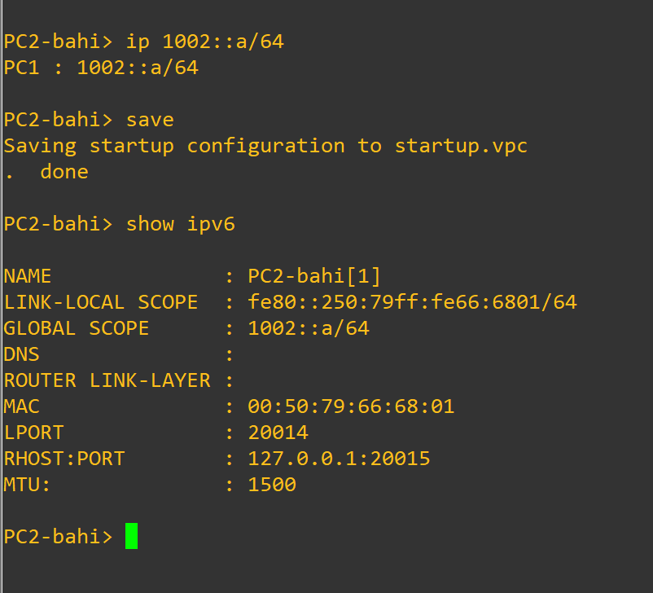

## Изменение имён маршрутизаторов VyOS

- Выполнен переход в режим конфигурирования
- Изменены системные имена маршрутизаторов
- Проверка выполнена командой `compare`
- Конфигурация применена (`commit`)
- Конфигурация сохранена (`save`)
- После перезагрузки имена вступили в силу

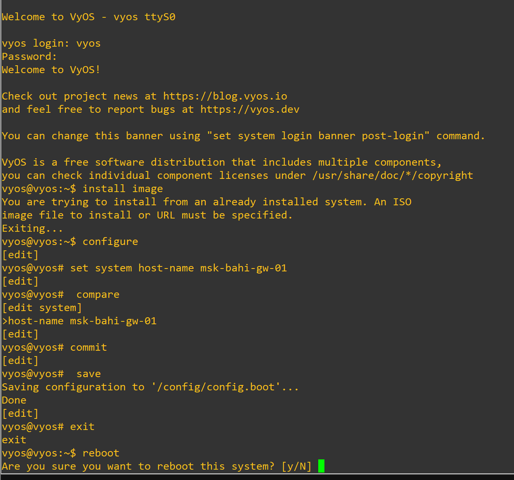

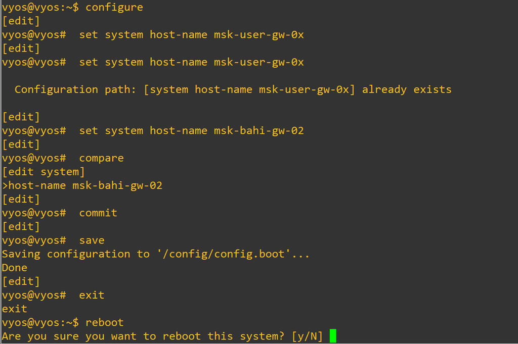

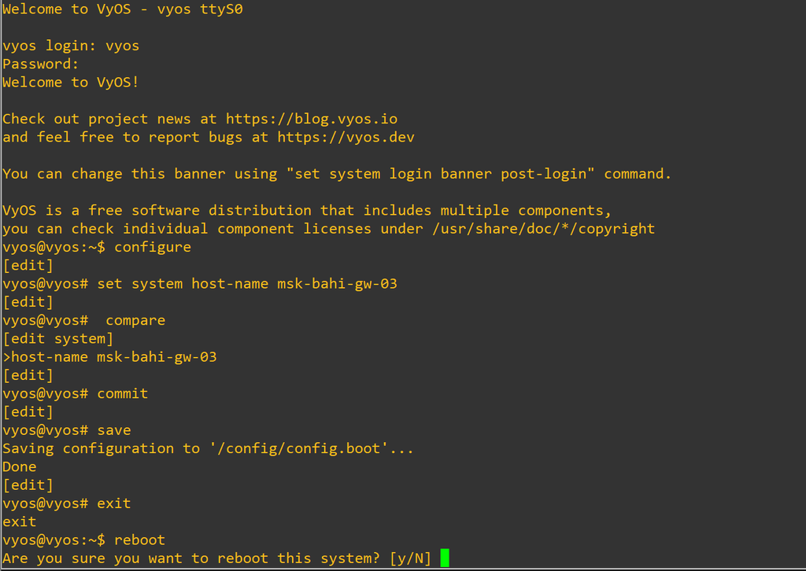

## Настройка IPv4- и IPv6-адресации на маршрутизаторах VyOS

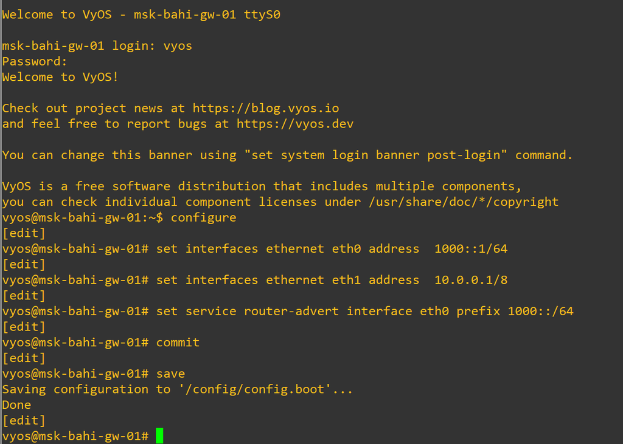

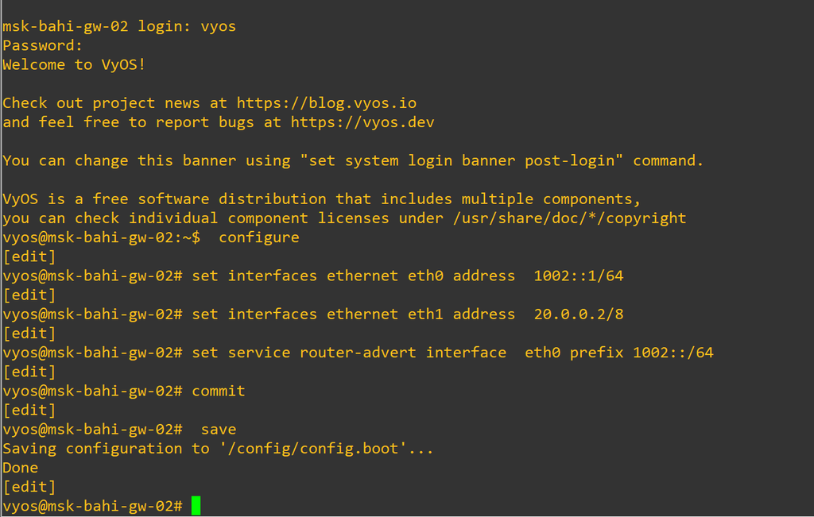

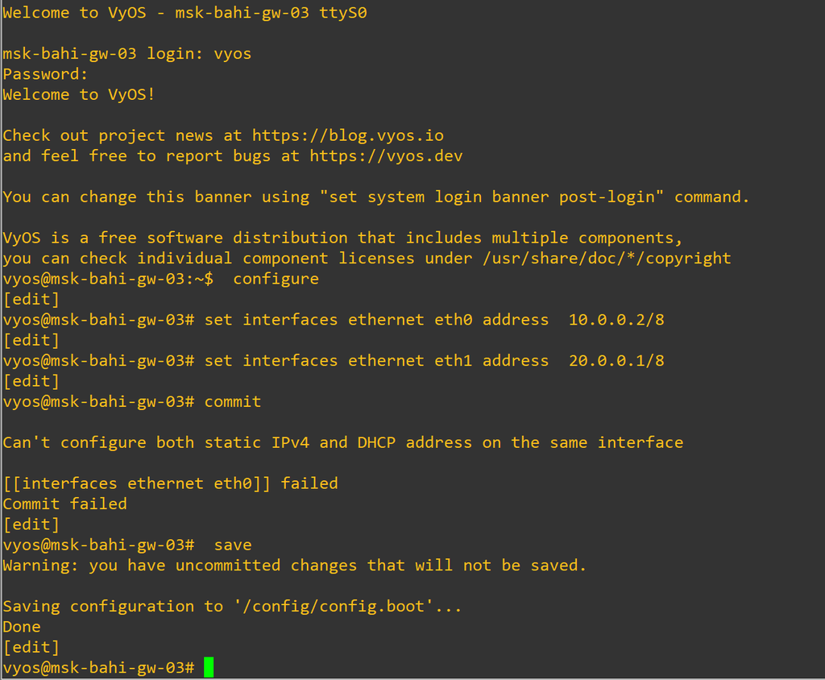

## Проверка получения IPv6-параметров по Router Advertisement

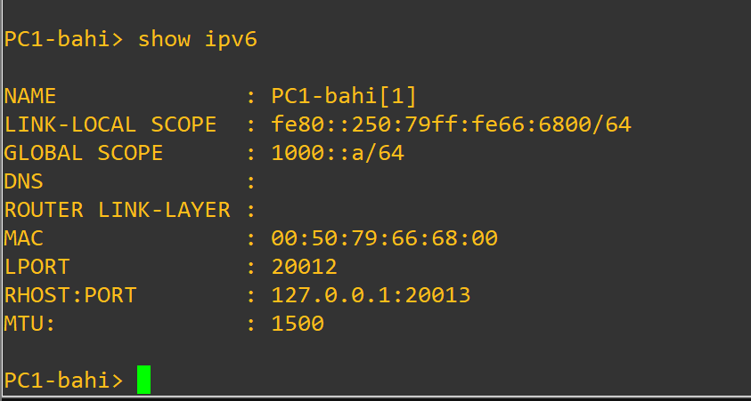

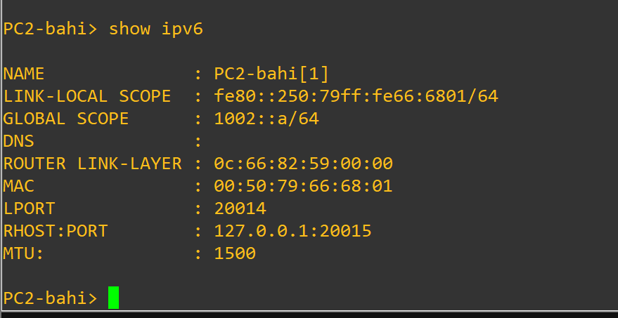

## Проверка связности до настройки маршрутизации

- Ping из `msk-bahi-gw-01` в сеть `10.0.0.0/8` успешен
- Подтверждена корректная IPv4-адресация
- Ping в сеть `20.0.0.0/8`:
  - Network is unreachable
- Отсутствует маршрут в таблице маршрутизации

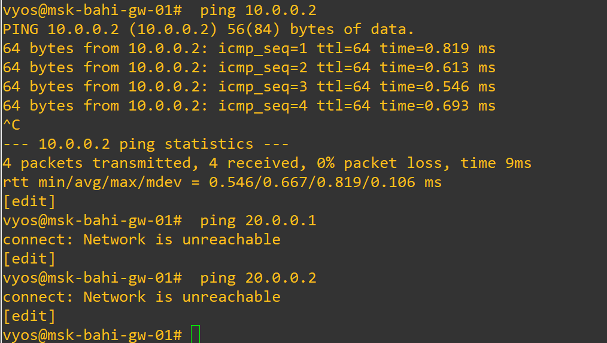

## Анализ ICMP-трафика IPv4

- ICMP Echo Request / Reply без потерь
- Подтверждена работа ARP
- Корректная передача данных в сети `10.0.0.0/8`
- При ping в `20.0.0.0/8` ICMP не формируется
- Трафик отбрасывается на этапе маршрутизации

[figure not shown]

## Настройка динамической маршрутизации IPv4 (RIP)

- Настроен протокол RIP на всех маршрутизаторах
- msk-bahi-gw-01:
  - сеть `10.0.0.0/8`
- msk-bahi-gw-02:
  - сеть `20.0.0.0/8`
- msk-bahi-gw-03:
  - транзит между сетями
- Маршрутизаторы обмениваются маршрутами
- Обеспечена IPv4-связность без статических маршрутов

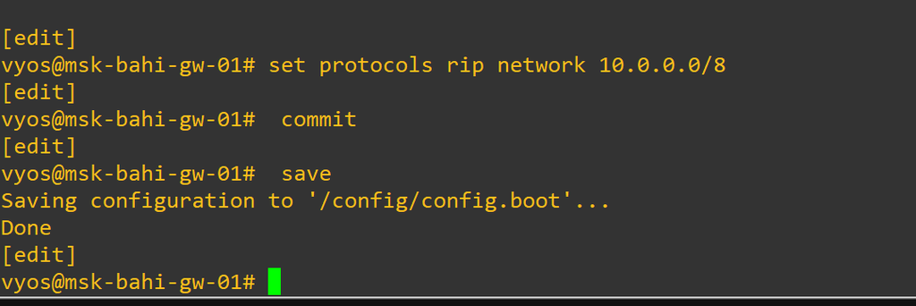

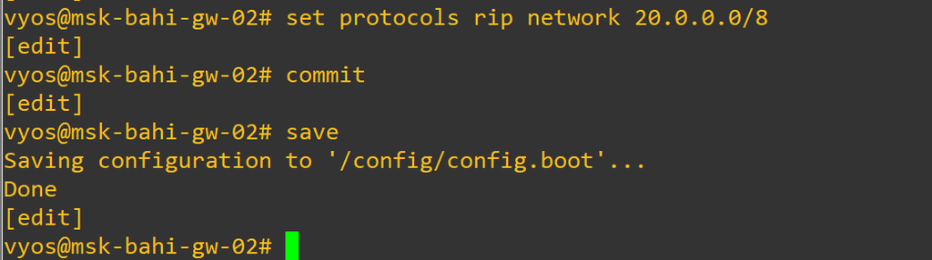

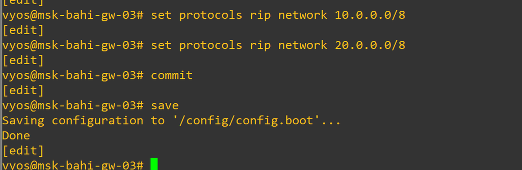

## Проверка маршрутов и анализ трафика (IPv4)

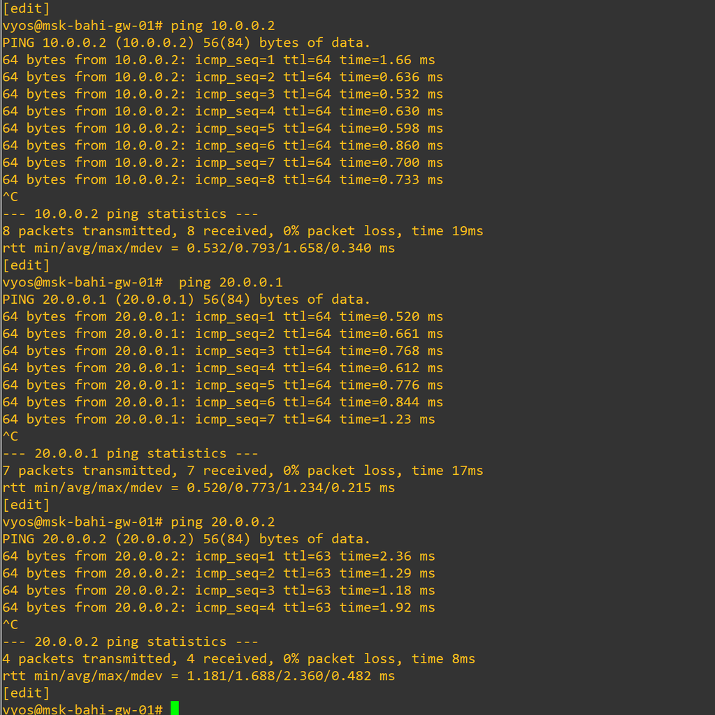

## Создание IPv6-туннеля поверх IPv4 (SIT)

- Настроен туннель tun0
- msk-bahi-gw-01
  - local IPv4: `10.0.0.1`
  - remote IPv4: `20.0.0.2`
  - IPv6: `1001::1/64`
- msk-bahi-gw-02
  - local IPv4: `20.0.0.2`
  - remote IPv4: `10.0.0.1`
  - IPv6: `1001::2/64`
- Туннель IPv6-over-IPv4 успешно создан

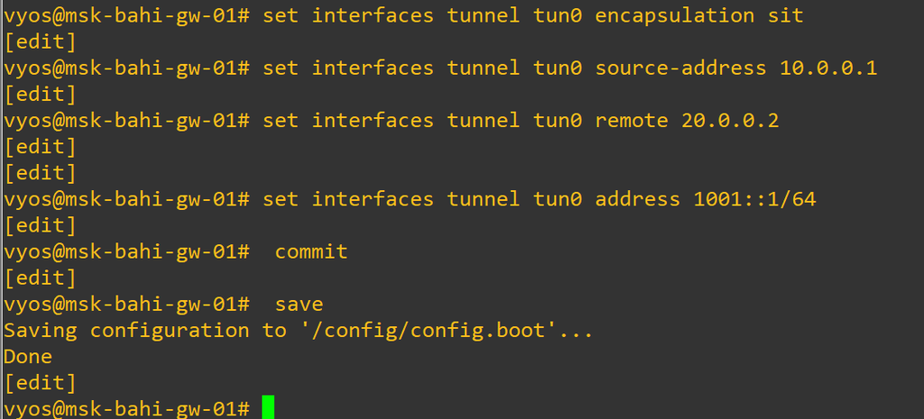

## Настройка статической маршрутизации IPv6

- msk-bahi-gw-01
  - маршрут `1002::/64` → `1001::2`
- msk-bahi-gw-02
  - маршрут `1000::/64` → `1001::1`
- Конфигурации применены и сохранены
- Обеспечена двусторонняя IPv6-маршрутизация

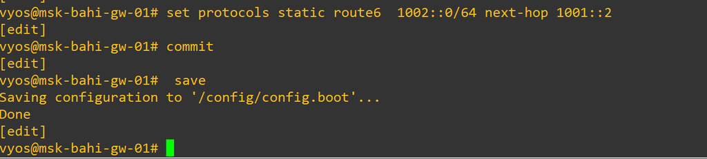

## Проверка IPv6-связности через туннель

- PC1:
  - `ping 1002::a`
  - `trace 1002::a`
- PC2:
  - `ping 1000::a`
  - `trace 1000::a`
- Трафик проходит через:
  - `1001::1 → 1001::2`
- В трафике:
  - IPv6 инкапсулирован в IPv4 (SIT)
  - Внешние IPv4-адреса: `10.0.0.1` ↔︎ `20.0.0.2`

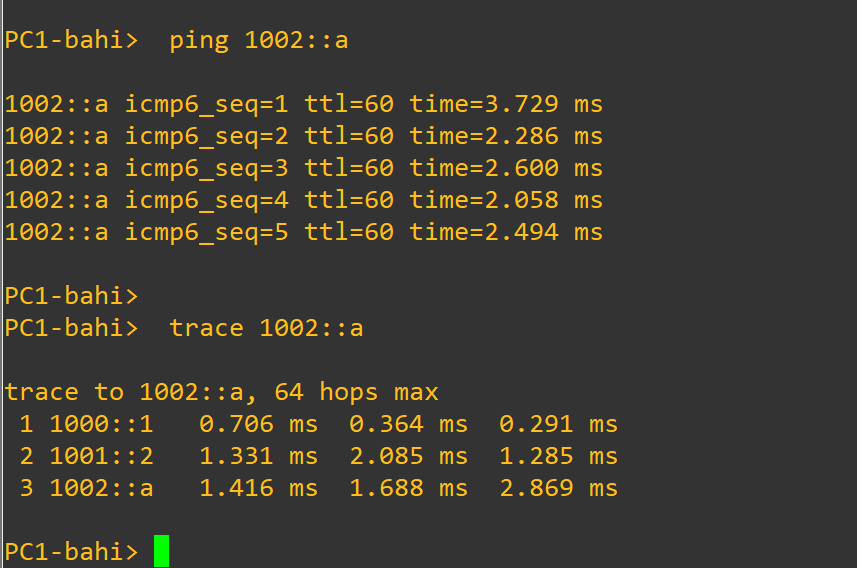

# Задание для самостоятельного выполнения

## Развёртывание топологии сети

- В GNS3 создан новый проект
- Развёрнута кольцевая топология из 4 маршрутизаторов
- Использованы:
  - 2 коммутатора
  - 2 узла VPCS
- PC1-user:
  - подключён к msk-user-gw-01
  - сети: `10.10.1.96/27`, `2001:DB8:1:1::/64`
- PC2-user:
  - подключён к msk-user-gw-02
  - сети: `10.10.1.64/28`, `2001:DB8:1:6::/64`
- Топология используется для анализа маршрутизации IPv4 / IPv6 ##

[figure not shown]

## Настройка IPv4-адресации на маршрутизаторе msk-bahi-gw-02

- Настроены интерфейсы:
  - eth0 — `10.10.1.65/28`
  - eth1 — `10.10.1.18/30`
  - eth2 — `10.10.1.33/30`
- Все интерфейсы активированы
- Конфигурация сохранена
- Проверка выполнена командой `show running-config`

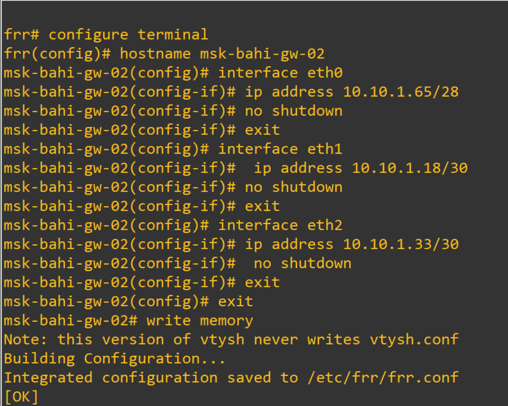

## Настройка IPv4-адресации на маршрутизаторе msk-bahi-gw-03

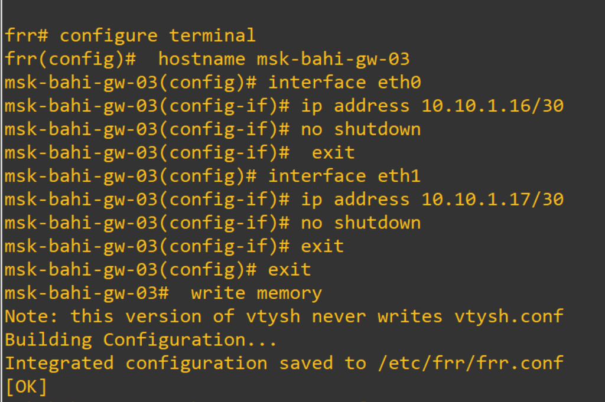

## Настройка IPv4-адресации на маршрутизаторе msk-bahi-gw-04

- Настроены интерфейсы:
  - eth0 — `10.10.1.9/30`
  - eth1 — `10.10.1.34/30`
- Интерфейсы активированы
- Конфигурация сохранена
- Проверка выполнена командой `show running-config`

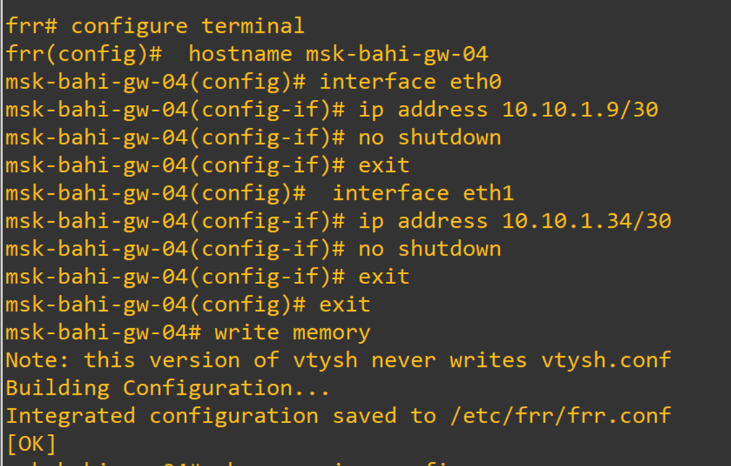

## Настройка IPv4-адресации на узле PC1-bahi

- Назначен IPv4-адрес:
  - `10.10.1.98/27`
- Шлюз по умолчанию:
  - `10.10.1.97`
- Конфигурация сохранена
- Проверка выполнена командой `show ip`

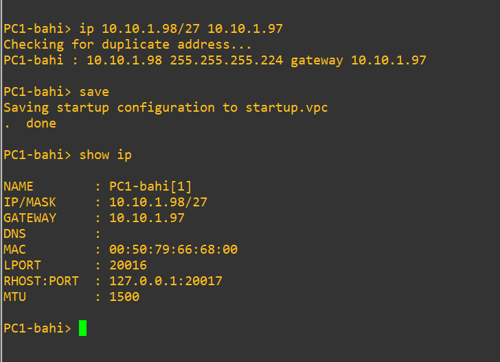

## Настройка IPv4-адресации на узле PC2-bahi

- Назначен IPv4-адрес:
  - `10.10.1.66/28`
- Шлюз по умолчанию:
  - `10.10.1.65`
- Конфигурация сохранена
- Параметры подтверждены командой `show ip`

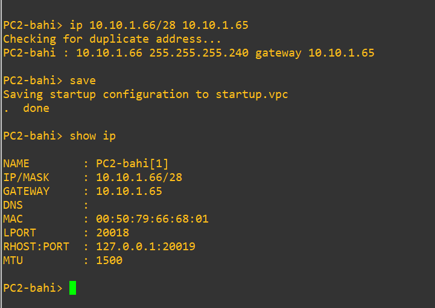

## Включение IPv6 и настройка интерфейсов на msk-bahi-gw-01

- Включена пересылка IPv6 (`ipv6 forwarding`)
- Интерфейс eth0:
  - IPv6 `2001:db8:1:1::1/64`
  - Включён Router Advertisement
  - Префикс `2001:db8:1:1::/64`
- Интерфейс eth1:
  - IPv6 `2001:db8:1:2::1/64`
- Конфигурация сохранена и проверена

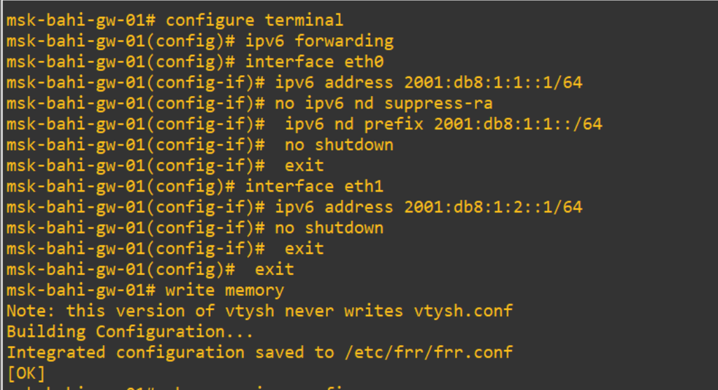

## Настройка IPv6-адресации на маршрутизаторе msk-bahi-gw-02

- Включена поддержка IPv6
- Назначены адреса:
  - eth0 — `2001:db8:1:6::1/64`
  - eth1 — `2001:db8:1:4::2/64`
  - eth2 — `2001:db8:1:5::2/64`
- Интерфейсы активированы
- Конфигурация сохранена

[figure not shown]

## Настройка IPv6-адресации на маршрутизаторе msk-bahi-gw-03

- Включена IPv6-маршрутизация
- Назначены адреса:
  - eth0 — `2001:db8:1:2::2/64`
  - eth1 — `2001:db8:1:4::1/64`
- Интерфейсы включены
- Конфигурация сохранена

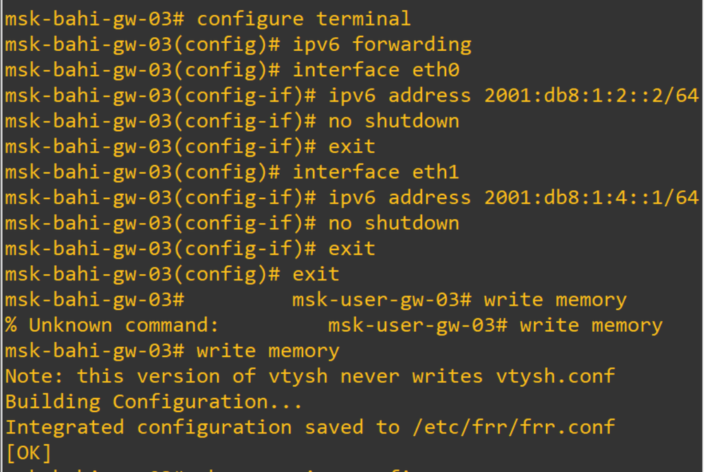

## Настройка IPv6-адресации на маршрутизаторе msk-bahi-gw-04

- Включён IPv6 forwarding
- Назначены адреса:
  - eth0 — `2001:db8:1:3::1/64`
  - eth1 — `2001:db8:1:5::1/64`
- Интерфейсы активированы
- Конфигурация сохранена

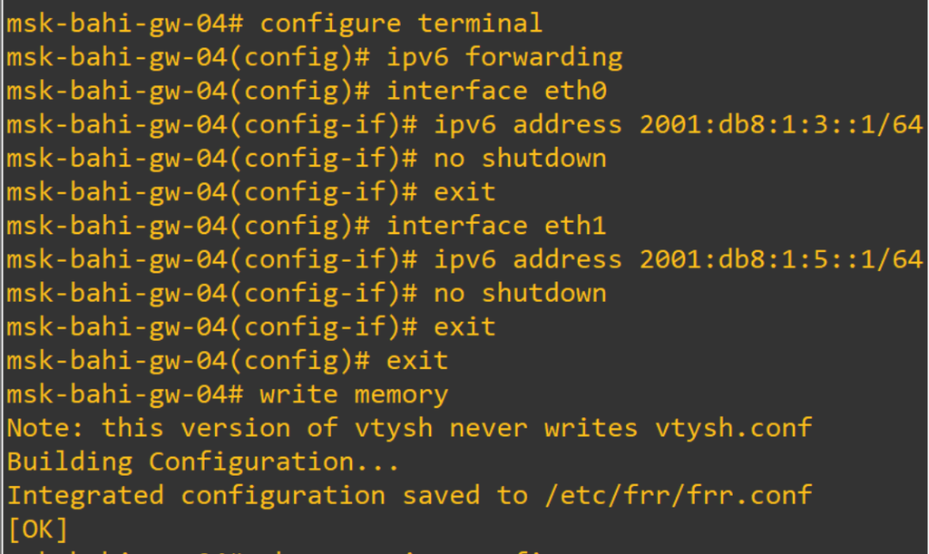

## Назначение IPv6-адреса на узле PC1-bahi

- Назначен глобальный IPv6-адрес:
  - `2001:db8:1:1::a/64`
- Конфигурация сохранена
- Проверка выполнена командой `show ipv6`
- Зафиксированы:
  - global IPv6
  - link-local IPv6

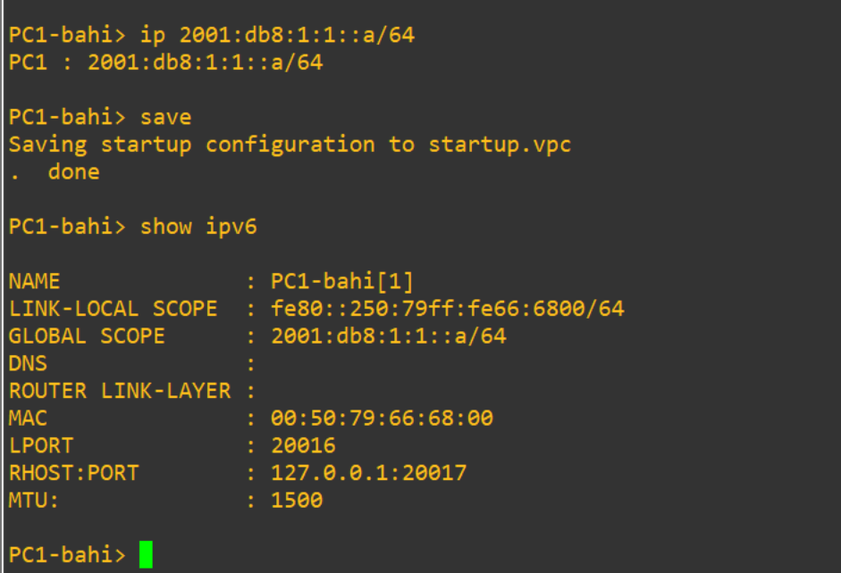

## Назначение IPv6-адреса на узле PC2-bahi

- Назначен IPv6-адрес:
  - `2001:db8:1:6::a/64`
- Конфигурация сохранена
- Проверка подтверждает корректное назначение адреса

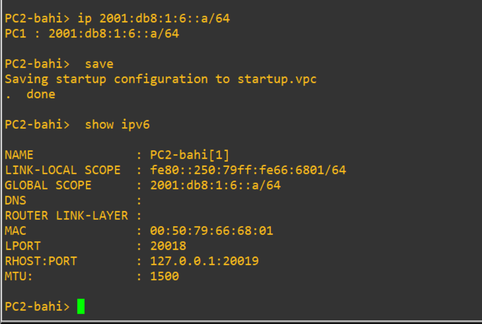

## Настройка и проверка RIP v2 на msk-bahi-gw-01

- Настроен RIP версии 2
- В процесс RIP добавлены:
  - eth0
  - eth1
  - eth2
- Получены маршруты:
  - `10.10.1.16/30`
  - `10.10.1.64/28`
- Next hop: `10.10.1.6`
- Проверка таблицы маршрутизации выполнена

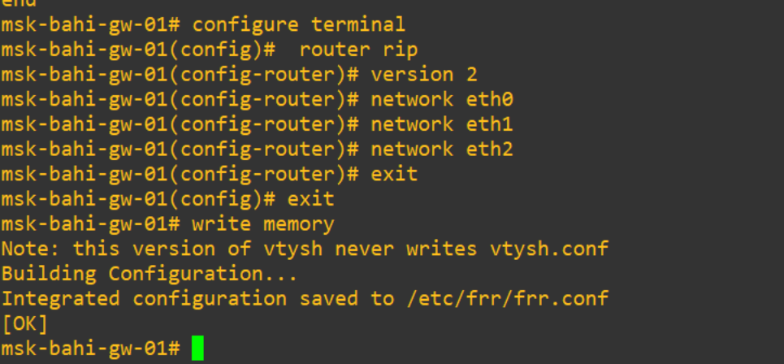

## Настройка и проверка RIP v2 на msk-bahi-gw-02

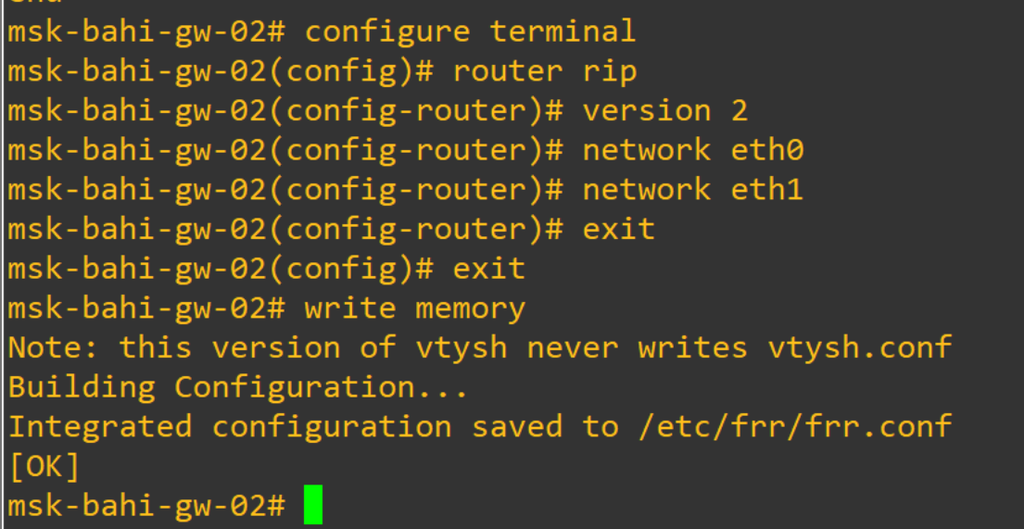

## Настройка и проверка RIP v2 на msk-bahi-gw-03

- Настроен RIP v2
- Интерфейсы:
  - eth0
  - eth1
  - eth2
- Получены маршруты:
  - `10.10.1.64/28`
  - `10.10.1.96/27`
- Источники:
  - `10.10.1.18`
  - `10.10.1.5`
- Подтверждена работа нескольких источников маршрутов

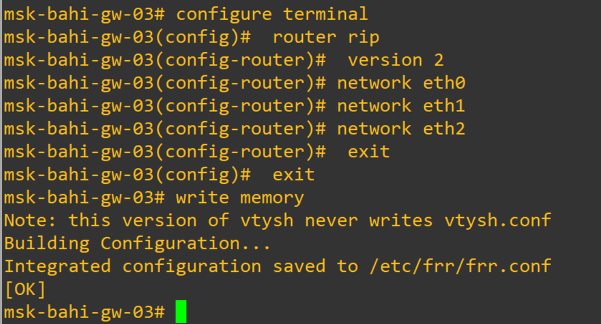

## Настройка и проверка RIP v2 на msk-bahi-gw-04

- Включён RIP v2
- Интерфейсы:
  - eth0
  - eth1
- В таблице RIP присутствуют:
  - `10.10.1.8/30`
  - `10.10.1.32/30`
- Конфигурация соответствует текущей топологии

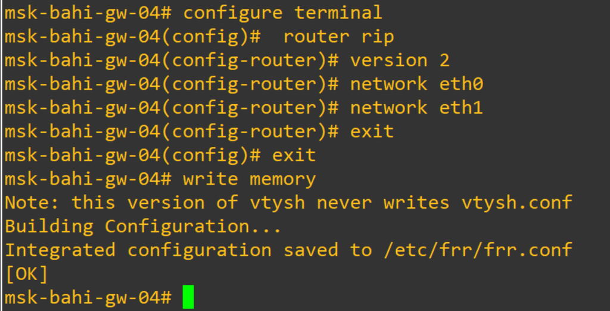

## Проверка IPv4-связности PC1-bahi → PC2-bahi

- Выполнен `ping 10.10.1.66`
- Все ICMP-пакеты получены без потерь
- Выполнена трассировка:
  - `10.10.1.97`
  - `10.10.1.6`
  - `10.10.1.18`
  - `10.10.1.66`
- Подтверждена корректная IPv4-маршрутизация

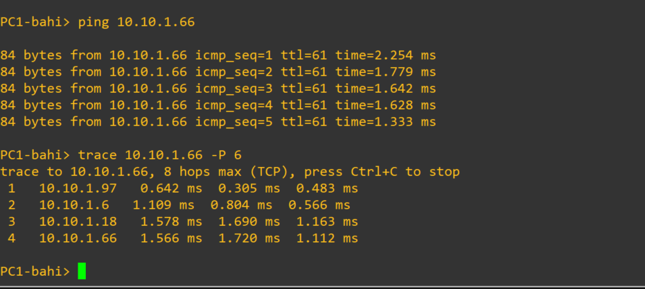

## Анализ таблицы маршрутизации RIP на msk-bahi-gw-01

- Просмотр выполнен командой `show ip rip`
- Присутствуют сети:
  - подключённые
  - динамически полученные
- Next hop: `10.10.1.6`
- Метрики соответствуют трассировке
- Подтверждён корректный RIP-обмен

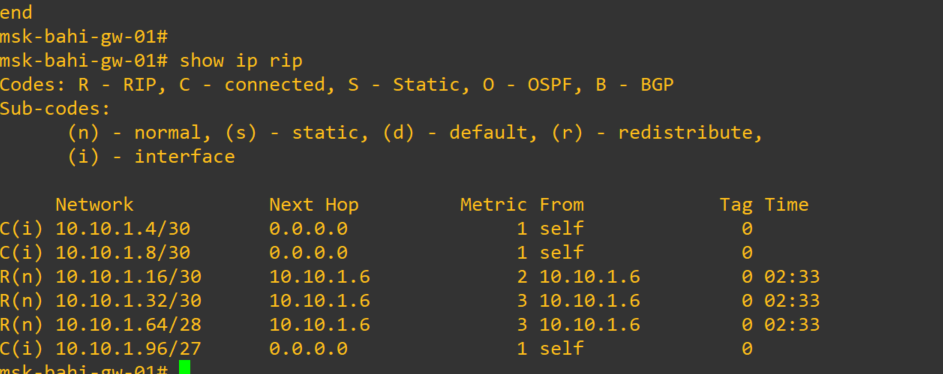

## Настройка RIPng на msk-bahi-gw-01

- Включён протокол RIPng
- Добавлены интерфейсы:
  - eth0
  - eth1
  - eth2
- Все IPv6-сегменты участвуют в маршрутизации
- Конфигурация сохранена

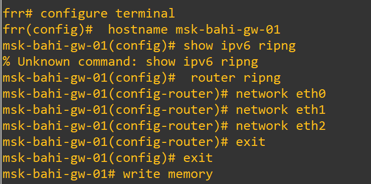

## Настройка RIPng на msk-bahi-gw-02

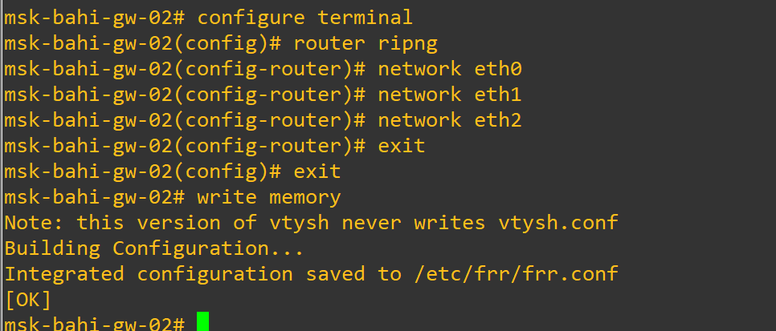

## Настройка RIPng на msk-bahi-gw-03

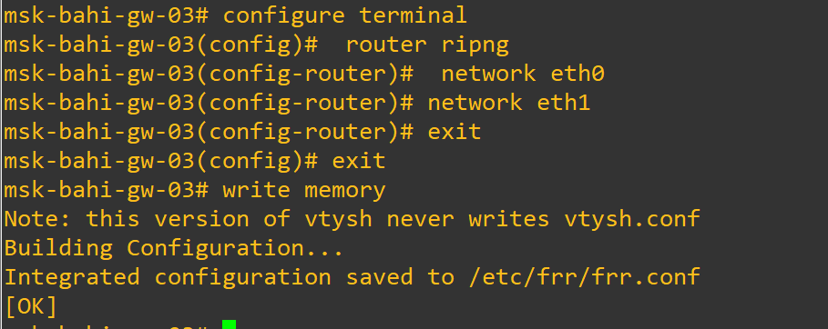

## Завершение настройки RIPng на маршрутизаторе msk-bahi-gw-04

- Включён протокол динамической маршрутизации IPv6 RIPng
- В процесс RIPng добавлены интерфейсы:
  - eth0
  - eth1
- Обеспечено участие соответствующих IPv6-сегментов в обмене маршрутами
- Конфигурация сохранена командой `write memory`

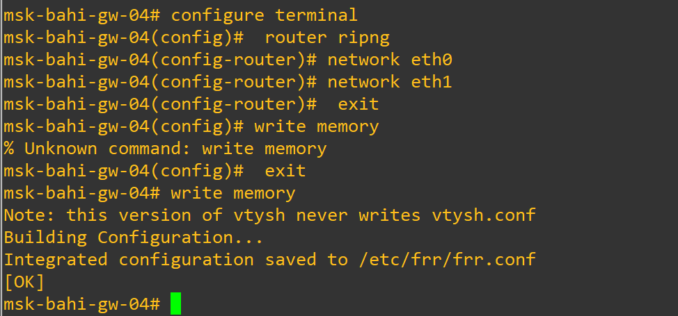

## Проверка IPv6-связности и трассировка маршрута с PC1-bahi

- С узла PC1-bahi выполнена команда:
  - `ping 2001:db8:1:6::a`
- Эхо-ответы не получены → отсутствует сквозная IPv6-связность
- Выполнена трассировка:
  - `trace 2001:db8:1:6::a`
- Зафиксирован маршрут:
  - 2001:db8:1:1::1
  - 2001:db8:1:2::2
  - 2001:db8:1:4::2
- Дальнейшая доставка пакетов не завершена

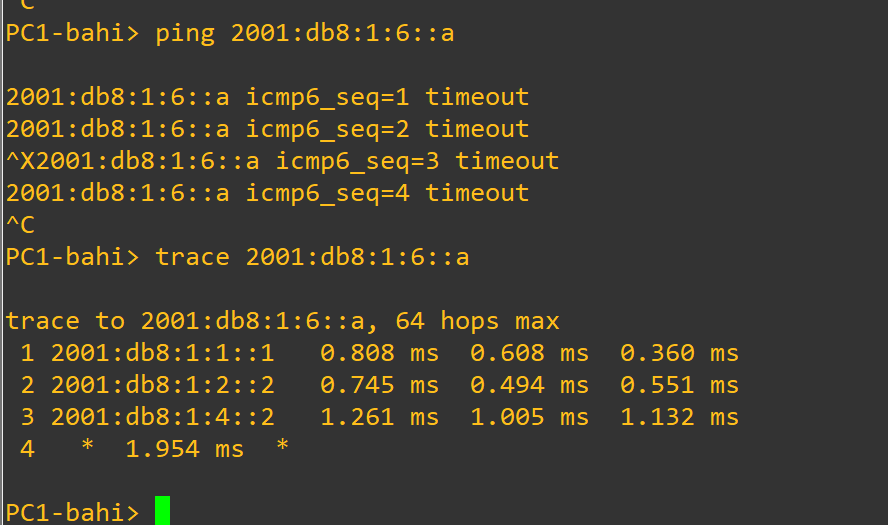